# Example: GLM for multinomial responses

# 1. A simulation showing the problem of using linear regression for ordinal response

(Chapter 6.2.5 of Agresti book)

We simulate data from the following model:
$$y_i^* = 2 + 0.6x_i - 4z_i + \epsilon_i$$

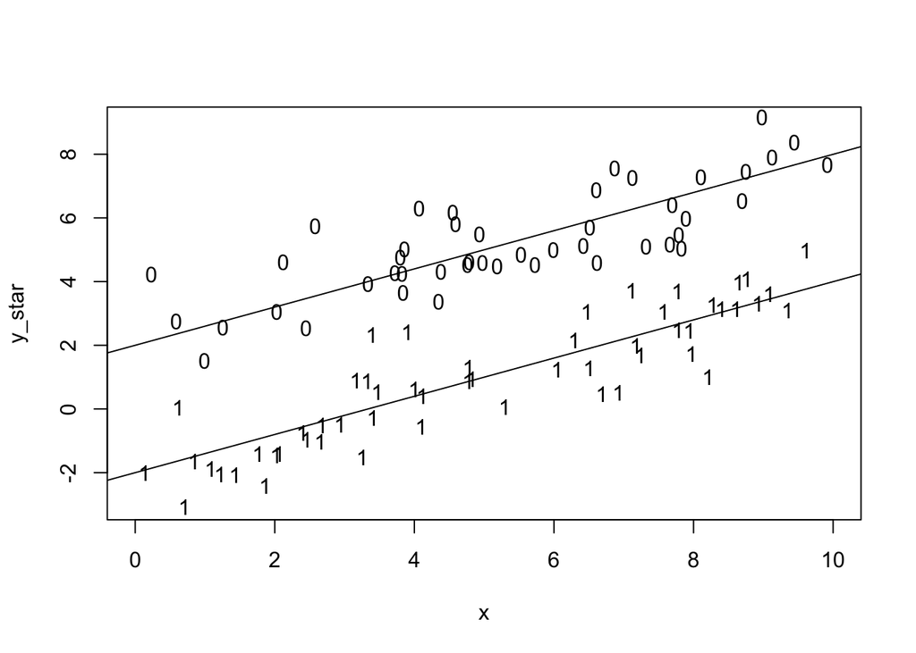

```r
set.seed(1)
n <- 100
x <- runif(n, 0, 10)
z <- rbinom(n, 1, 0.5)
epsilon <- rnorm(n, 0, 1)
y_star <- 2 + 0.6 * x - 4 * z + epsilon
pch <- rep("1", n)
pch[z == 0] <- "0"
plot(x, y_star, pch = pch, xlim = c(0, 10), ylim = c(-3, 9))
abline(2, 0.6)
abline(-2, 0.6)
```

This figure shows the relationship between $x$ and $y^*$ at two levels of $z$. Clearly, there is no interaction between $x$ and $z$ in affecting $y^*$.

## 1.1 Using a linear model

Now consider the scenario that we can only measure $y$, a discretized version of $y^*$.

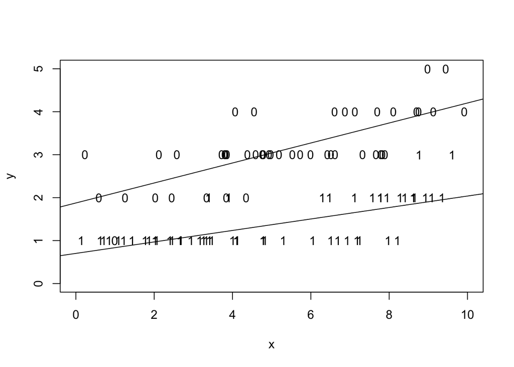

```r
y <- rep(1, n)
y[y_star > 2 & y_star <=4] <- 2
y[y_star > 4 & y_star <=6] <- 3
y[y_star > 6 & y_star <=8] <- 4
y[y_star > 8] <- 5
lm.fit1 <- lm(y[z == 1] ~ x[z==1])
lm.fit2 <- lm(y[z == 0] ~ x[z==0])
plot(x, y, pch = pch, xlim = c(0, 10), ylim = c(0, 5))
abline(lm.fit1$coefficients[1], lm.fit1$coefficients[2])
abline(lm.fit2$coefficients[1], lm.fit2$coefficients[2])
```

One can see that each category has different variances

```r
lm.fit3 <- lm(y ~ x + z + x:z)
summary(lm.fit3)
```

```
##
## Call:
## lm(formula = y ~ x + z + x:z)
##
## Residuals:
##      Min       1Q   Median       3Q      Max
## -1.10736 -0.34012  0.01254  0.23616  1.17697
##
## Coefficients:
##             Estimate Std. Error t value Pr(>|t|)
## (Intercept)  1.87577    0.17175  10.921  < 2e-16 ***
## x            0.23284    0.02894   8.045 2.28e-12 ***
## z           -1.17386    0.21924  -5.354 5.86e-07 ***
## x:z         -0.09913    0.03747  -2.646  0.00952 **
## ---
## Signif. codes:  0 '***' 0.001 '**' 0.01 '*' 0.05 '.' 0.1 ' ' 1
##
## Residual standard error: 0.4881 on 96 degrees of freedom
## Multiple R-squared:  0.8137, Adjusted R-squared:  0.8079
## F-statistic: 139.8 on 3 and 96 DF,  p-value: < 2.2e-16
```

Incorrect inference of the interaction due to a flooring effect and a ceiling effect. In contrast, if we can observe $y^*$, we can pbtain the current estimation.

```r
lm.fit4 <- lm(y_star ~ x + z + x:z)
summary(lm.fit4)
```

```
##
## Call:
## lm(formula = y_star ~ x + z + x:z)
##
## Residuals:
##     Min      1Q  Median      3Q     Max
## -1.9498 -0.5791 -0.1286  0.5798  2.4582
##
## Coefficients:
##             Estimate Std. Error t value Pr(>|t|)
## (Intercept)  2.44125    0.33727   7.238 1.12e-10 ***
## x            0.52209    0.05683   9.187 8.31e-15 ***
## z           -4.72214    0.43051 -10.969  < 2e-16 ***
## x:z          0.11644    0.07358   1.583    0.117
## ---
## Signif. codes:  0 '***' 0.001 '**' 0.01 '*' 0.05 '.' 0.1 ' ' 1
##
## Residual standard error: 0.9584 on 96 degrees of freedom
## Multiple R-squared:  0.8906, Adjusted R-squared:  0.8871
## F-statistic: 260.4 on 3 and 96 DF,  p-value: < 2.2e-16
```

## 1.2 Using a cumulative probit model

Instead, if we use a cumulative link model, we can correctly identify that there is no interaction between $x$ and $z$. As $\epsilon$ follows a normal distribution, use use a cumulative probit model.

```r
library(VGAM)
fit <- suppressWarnings(vglm(y ~ x + z + x:z, family = cumulative(link = "probitlink", parallel = T)))
summary(fit)
```

```
##
## Call:
## vglm(formula = y ~ x + z + x:z, family = cumulative(link = "probitlink",
##     parallel = T))
##
## Pearson residuals:
##                        Min         1Q    Median      3Q    Max
## probitlink(P[Y<=1]) -3.499 -1.591e-01 -0.006832 0.18263 2.4354
## probitlink(P[Y<=2]) -2.253 -1.351e-01  0.009128 0.15963 2.0628
## probitlink(P[Y<=3]) -3.574  6.988e-05  0.008994 0.13790 1.2357
## probitlink(P[Y<=4]) -1.953  3.658e-06  0.001032 0.04755 0.8009
##
## Coefficients:
##               Estimate Std. Error z value Pr(>|z|)
## (Intercept):1 -0.62218    0.47087  -1.321   0.1864
## (Intercept):2  1.08514    0.42447   2.556   0.0106 *
## (Intercept):3  3.27600    0.62037   5.281 1.29e-07 ***
## (Intercept):4  4.85644    0.78166   6.213 5.20e-10 ***
## x             -0.44869    0.09002  -4.984 6.22e-07 ***
## z              3.49280    0.83168   4.200 2.67e-05 ***
## x:z            0.02389    0.12895   0.185   0.8530
## ---
## Signif. codes:  0 '***' 0.001 '**' 0.01 '*' 0.05 '.' 0.1 ' ' 1
##
## Names of linear predictors: probitlink(P[Y<=1]), probitlink(P[Y<=2]),
## probitlink(P[Y<=3]), probitlink(P[Y<=4])
##
## Residual deviance: 123.7853 on 393 degrees of freedom
##
## Log-likelihood: NA on 393 degrees of freedom
##
## Number of Fisher scoring iterations: 12
##
##
## Exponentiated coefficients:
##          x          z        x:z
##  0.6384641 32.8779657  1.0241817
```

Question: what are the true values of the estimated coefficients?

# 2. Data examples

## 2.1 Chapter 6.3.2, Nominal response, Alligator Food Choice

```r
Alligators <- read.table("Alligators.dat", header = T)
Alligators
```

| lake | size | y1 | y2 | y3 | y4 | y5 |
| --- | --- | --- | --- | --- | --- | --- |
| 1 | 1 | 23 | 4 | 2 | 2 | 8 |
| 1 | 0 | 7 | 0 | 1 | 3 | 5 |
| 2 | 1 | 5 | 11 | 1 | 0 | 3 |
| 2 | 0 | 13 | 8 | 6 | 1 | 0 |
| 3 | 1 | 5 | 11 | 2 | 1 | 5 |
| 3 | 0 | 8 | 7 | 6 | 3 | 5 |
| 4 | 1 | 16 | 19 | 1 | 2 | 3 |
| 4 | 0 | 17 | 1 | 0 | 1 | 3 |

- y1: Fish, y2: Invertebrate, y3: Reptile, y4: Bird, y5: Other
- lake: 1 = Hancock, 2 = Ocklawaha, 3 = Trafford, 4 = George
- size: 1 = Alligator size > 2.3m, 0 = Alligator size <= 2.3m

This is a dataset with grouped multinomial responses.

We can use a Baseline-category logit model. Using the first category as the baseline, we have

```r
library(VGAM)
fit <- vglm(formula = cbind(y2, y3, y4, y5, y1) ~ size + factor(lake), family = multinomial, data = Alligators)
summary(fit)
```

```
##
## Call:
## vglm(formula = cbind(y2, y3, y4, y5, y1) ~ size + factor(lake),
##     family = multinomial, data = Alligators)
##
## Pearson residuals:
##   log(mu[,1]/mu[,5]) log(mu[,2]/mu[,5]) log(mu[,3]/mu[,5]) log(mu[,4]/mu[,5])
## 1             0.0953           0.028205           -0.54130            -0.7268
## 2            -0.5082           0.003228            0.66646             1.2589
## 3            -0.3693          -0.461102           -0.42005             1.8347
## 4             0.4125           0.249983            0.19772            -1.3779
## 5            -0.5526          -0.191149            0.07215             0.2790
## 6             0.6500           0.110694           -0.02784            -0.2828
## 7             0.6757           0.827737            0.79863            -0.3081
## 8            -1.3051          -0.802694           -0.69525             0.4629
##
## Coefficients:
##                 Estimate Std. Error z value Pr(>|z|)
## (Intercept):1    -3.2074     0.6387  -5.021 5.13e-07 ***
## (Intercept):2    -2.0718     0.7067  -2.931 0.003373 **
## (Intercept):3    -1.3980     0.6085  -2.297 0.021601 *
## (Intercept):4    -1.0781     0.4709  -2.289 0.022061 *
## size:1            1.4582     0.3959   3.683 0.000231 ***
## size:2           -0.3513     0.5800  -0.606 0.544786
## size:3           -0.6307     0.6425  -0.982 0.326296
## size:4            0.3316     0.4482   0.740 0.459506
## factor(lake)2:1   2.5956     0.6597   3.934 8.34e-05 ***
## factor(lake)2:2   1.2161     0.7860   1.547 0.121824
## factor(lake)2:3  -1.3483     1.1635  -1.159 0.246529
## factor(lake)2:4  -0.8205     0.7296  -1.125 0.260713
## factor(lake)3:1   2.7803     0.6712   4.142 3.44e-05 ***
## factor(lake)3:2   1.6925     0.7804   2.169 0.030113 *
## factor(lake)3:3   0.3926     0.7818   0.502 0.615487
## factor(lake)3:4   0.6902     0.5597   1.233 0.217511
## factor(lake)4:1   1.6584     0.6129   2.706 0.006813 **
## factor(lake)4:2  -1.2428     1.1854  -1.048 0.294466
## factor(lake)4:3  -0.6951     0.7813  -0.890 0.373608
## factor(lake)4:4  -0.8262     0.5575  -1.482 0.138378
## ---
## Signif. codes:  0 '***' 0.001 '**' 0.01 '*' 0.05 '.' 0.1 ' ' 1
##
## Names of linear predictors: log(mu[,1]/mu[,5]), log(mu[,2]/mu[,5]),
## log(mu[,3]/mu[,5]), log(mu[,4]/mu[,5])
##
## Residual deviance: 17.0798 on 12 degrees of freedom
##
## Log-likelihood: -47.5138 on 12 degrees of freedom
##
## Number of Fisher scoring iterations: 5
##
## Warning: Hauck-Donner effect detected in the following estimate(s):
## '(Intercept):1'
##
##
## Reference group is level  5  of the response
```

We can check whether we need a more complicated model by LRT test of the residual deviance

```r
1 - pchisq(17.0798, df = 12)
```

```
## [1] 0.1466201
```

This indicates that interactions are not needed.

Both the lake and size main effects are needed.

```r
library(VGAM)
fit.nosize <- vglm(formula = cbind(y2, y3, y4, y5, y1) ~ factor(lake), family = multinomial, data = Alligators)
anova(fit.nosize, fit, type = "I")
```

|  | Resid. Df | Resid. Dev | Df | Deviance | Pr(>Chi) |
| --- | --- | --- | --- | --- | --- |
| 1 | 16 | 38.16724 | NA | NA | NA |
| 2 | 12 | 17.07983 | 4 | 21.08741 | 0.0003042796 |

The fitted probabilities

```r
fitted(fit)
```

```
##           y2         y3          y4         y5        y1
## 1 0.09309880 0.04745657 0.070401523 0.25373963 0.5353035
## 2 0.02307168 0.07182461 0.140896287 0.19400964 0.5701978
## 3 0.60189675 0.07722761 0.008817482 0.05387208 0.2581861
## 4 0.24864518 0.19483742 0.029416085 0.06866281 0.4584385
## 5 0.51683852 0.08876722 0.035894709 0.17420051 0.1842990
## 6 0.19296122 0.20239954 0.108225068 0.20066164 0.2957525
## 7 0.41285579 0.01156654 0.029671169 0.09380245 0.4521040
## 8 0.13967784 0.02389871 0.081067366 0.09791362 0.6574425
```

y1: Fish, y2: Invertebrate, y3: Reptile, y4: Bird, y5: Other

## 2.2 Chapter 6.3.3, Ordinal response, Mental Impairment

Mental impairment is ordinal: 1 = well, 2 = mild symptom formation, 3 = moderate symptom formation, 4 = impaired

```r
Mental <- read.table("Mental.dat", header = T)
Mental
```

| impair | ses | life |
| --- | --- | --- |
| 1 | 1 | 1 |
| 1 | 1 | 9 |
| 1 | 1 | 0 |
| 1 | 1 | 4 |
| 1 | 1 | 3 |
| 1 | 0 | 2 |
| 1 | 0 | 1 |
| 1 | 1 | 3 |
| 1 | 1 | 3 |
| 1 | 1 | 7 |

[output cut: 30 more lines]

```r
#table(Mental$impair)
```

- life: life events index, measuring the number of severity of important life events happend in the past three years
- ses: socioeconomic status 1 = high 0 = low

```r
fit <- vglm(impair ~ life + ses, family = cumulative(link = "logitlink", parallel = T), data = Mental)
summary(fit)
```

```
##
## Call:
## vglm(formula = impair ~ life + ses, family = cumulative(link = "logitlink",
##     parallel = T), data = Mental)
##
## Pearson residuals:
##                       Min      1Q  Median     3Q   Max
## logitlink(P[Y<=1]) -1.568 -0.7048 -0.2102 0.8070 2.713
## logitlink(P[Y<=2]) -2.328 -0.4666  0.2657 0.6904 1.615
## logitlink(P[Y<=3]) -3.688  0.1198  0.2039 0.4194 1.892
##
## Coefficients:
##               Estimate Std. Error z value Pr(>|z|)
## (Intercept):1  -0.2819     0.6231  -0.452  0.65096
## (Intercept):2   1.2128     0.6511   1.863  0.06251 .
## (Intercept):3   2.2094     0.7171   3.081  0.00206 **
## life           -0.3189     0.1194  -2.670  0.00759 **
## ses             1.1112     0.6143   1.809  0.07045 .
## ---
## Signif. codes:  0 '***' 0.001 '**' 0.01 '*' 0.05 '.' 0.1 ' ' 1
##
## Names of linear predictors: logitlink(P[Y<=1]), logitlink(P[Y<=2]),
## logitlink(P[Y<=3])
##
## Residual deviance: 99.0979 on 115 degrees of freedom
##
## Log-likelihood: -49.5489 on 115 degrees of freedom
##
## Number of Fisher scoring iterations: 5
##
## No Hauck-Donner effect found in any of the estimates
##
##
## Exponentiated coefficients:
##      life       ses
## 0.7269742 3.0380707
```

Intepretation for the sign of the coefficients: a positive coefficient represents a negative effect on $y_i$.

We check if the proportional odds assumption is reasonable by comparing with a more flexible model allowing different $\beta$ for different category $k$.

```r
fit.nonpo <- vglm(impair ~ life + ses, family = cumulative(link = "logitlink", parallel = F), data = Mental)
anova(fit, fit.nonpo, type = "I")
```

|  | Resid. Df | Resid. Dev | Df | Deviance | Pr(>Chi) |
| --- | --- | --- | --- | --- | --- |
| 1 | 115 | 99.09790 | NA | NA | NA |
| 2 | 111 | 96.74859 | 4 | 2.349308 | 0.6718069 |

```r
#1 - pchisq(2 * (logLik(fit.nonpo) - logLik(fit)), df = df.residual(fit) - df.residual(fit.nonpo))
```

The p-value is not small enough to reject